# Emergy — Odum’s quality-of-energy lens

### Bundle Q3.37 — A proper Raworth-Doughnut × SDG-wheel × emergy overlay

Until now, our “Doughnut” visualization was a horizontal-bar forest of ΔR² values, projected onto Doughnut framing but rendered as a coefficient plot. Q3.37 delivers the **actual Raworth ring** — a per-country figure showing 12 social-floor spokes inside a green safe-and-just band, 9 ecological-ceiling spokes outside, with the 17-goal UN SDG palette wrapping the whole thing, and emergy candidates layered on as yellow dots at their SDG-tagged angular positions.

New `emburdenvis` primitives (all `@export`’d):

- `donut_ring()` / `plot_country_doughnut()` — the Raworth ring itself.
- `sdg_ring()` — 17-segment outer ring, canonical UN colours.
- `emergy_wedge_overlay()` — SDG-tagged emergy candidate dots.
- `emergy_trajectory_overlay()` — panel-year trajectory dots.
- `donut_long()` — melts the Q3.36B wide snapshot into long form.
- `sdg_official_colors()` — UN 17-goal palette added to the brand.

The 21D snapshot builder (`build_donut_country_snapshot.R`) now persists **continuous signed distance-from-boundary** alongside the binary breach flags, so each spoke’s length encodes the *magnitude* of the shortfall or overshoot rather than a yes/no.

**Twelve exemplar countries** (4 quadrants × 3 exemplars each) as small multiples:

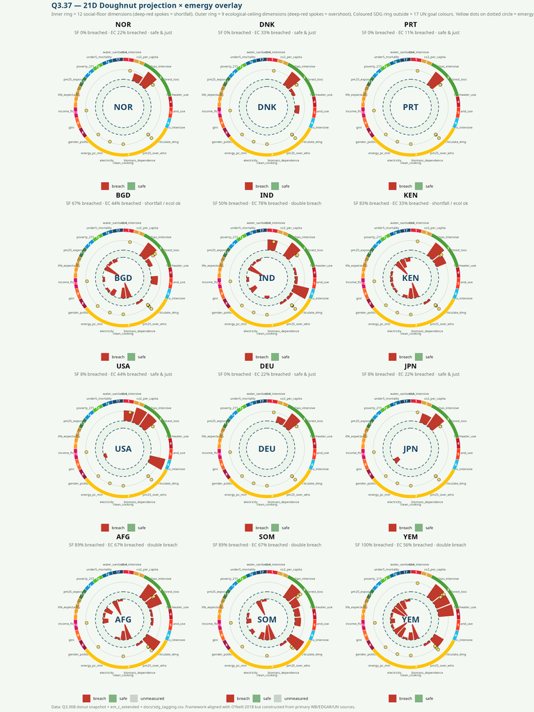

Doughnut small multiples, 12 countries

**Trajectory overlay** — for 6 emergy metrics (transformity, renewable share, ELR, EYR, ESI, empower per capita) plotted as year-coloured dots on their radial axes across 2000-2025. Watch USA’s ESI drift, DEU’s renewable share climb, AFG’s biomass burden persist.

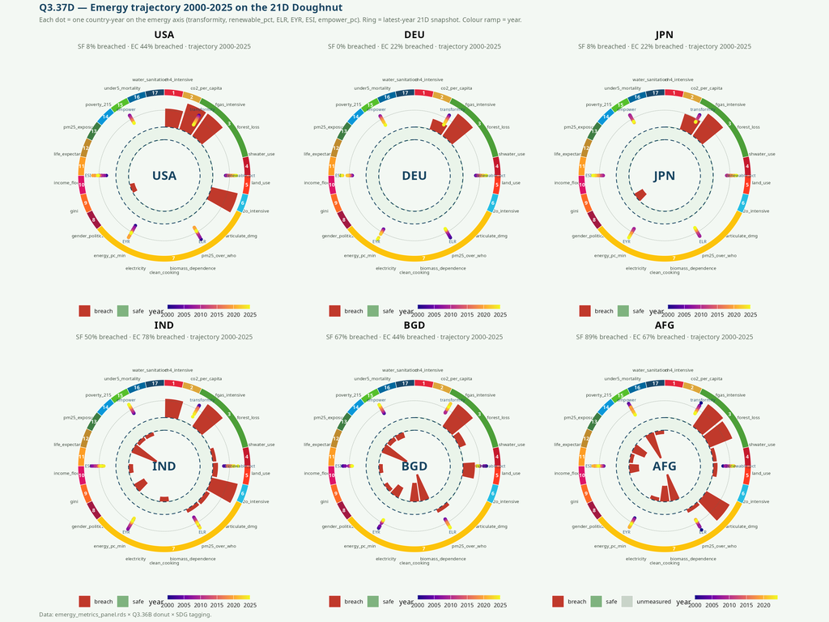

Doughnut trajectory grid, 6 countries

**How to read one panel** (e.g. `AFG` above):

- **Inner ring** = 12 social-floor dimensions. Deep-red spokes point inward from the safe boundary — the wedge length is the magnitude of the shortfall. AFG has 8/9 measured SF spokes breached.
- **Green band between the dashed circles** = safe & just Doughnut interior.
- **Outer ring** = 9 ecological-ceiling dimensions. Deep-red spokes overshoot outward. AFG has 6/9 measured — F-gas intensive is the extreme (this reflects Q3.33’s Kigali finding that AFG is a Group II high-growth F-gas country).
- **Coloured outer band** = 17-segment SDG official palette.
- **Yellow dots on the dotted circle** = the SDG-tagged emergy candidates (from `docs/sdg_tagging.csv`) at their z-scored country values.

Details at [`docs/donut_wheels/`](https://github.com/ericscheier/emburdensynth/tree/global/docs/donut_wheels). Underlying helpers at [`emburdenvis/R/donut_wheel.R`](https://github.com/ericscheier/emburdenvis/blob/main/R/donut_wheel.R).

### Bundle Q3.51 / Q3.52 — Electrotech Revolution, emergy-first

In September 2026 Ember Futures published *The Electrotech Revolution* — a 112-page deck arguing that a coupled family of electric technologies (solar / wind + batteries + EVs / heat pumps + electrified industry + grid digitalisation) has become the dominant driver of energy-system change. Ember’s operational definition of “electrotech” is carrier-based: electric-share-of-final-energy plus a checklist of electric machines. Q3.51 built an alternative emergy + information- energy definition; Q3.52 showed that the emergy definition is a strict umbrella over Ember’s, and used the extra headroom to fill two nodes Ember leaves quantitatively empty: **energy services** and **prosperity**.

**Umbrella containment.** For each end-use technology $t$ we score

$$s(t) = \frac{E_j(t)\,\tau_e + B(t)\,\tau_i}
{E_j(t)\,\tau_e + B(t)\,\tau_i + T_j(t)\,\tau_f}$$

where $E_j$ and $T_j$ are the electric- and thermal-Joules delivered per service-hour, $B$ is the bits of control-loop information circulated per service-hour, $\tau_e$ is the country grid transformity, $\tau_f$ is the combustion-fuel transformity, and $\tau_i \approx 10^{7}$ seJ/bit is Odum’s information transformity for microcontroller-scale control-loop bits. Setting $\tau_i \to 0$ and $\tau_e = \tau_f$ collapses $s(t)$ to $E_j / (E_j + T_j)$, which is Ember’s carrier share at the technology level. Aggregated over service-hours it becomes Ember’s headline electric-share-of-final-energy. The emergy definition therefore contains Ember’s; both agree on the supply-side carrier axis and diverge only where the information layer or the electron-carrier premium earn weight.

**Two orthogonal transitions.** Ember conflates them; we separate. The **emergy transition** (Odum’s original) is movement up the transformity ladder. The **information transition** is movement up the information-density ladder — the control layer story that Ember gestures at on slides 6, 21, 74, 87 but does not measure. Countries can climb one without the other. Ranking the 213 iso3s by carrier – emergy gap:

[output not shown]

Positive gaps = “wires without control”: high electricity share of demand, tech-mix still dominated by ICE / gas boilers / blast-furnace steel. Negative gaps = control ahead of wires. The 16-technology reference table (`electrotech_transformity.csv` at [`emburdensynth/inst/extdata/`](https://github.com/ericscheier/emburdensynth/blob/global/inst/extdata/electrotech_transformity.csv)) gives each end-use a canonical bits-per-service-hour, electric-J-per- service-hour, and thermal-J-per-service-hour, spanning transport (EV / ICE / DC-fast-charger), buildings (heat pump / gas boiler / LED / incandescent / induction / gas cooker), and industry (EAF / BF-BOF steel / VSD / fixed-speed motor / **data center** / crypto ASIC).

**Data centers as an electrotech technology.** Ember slide 87 lists data centres as their own line in the 2024–2030 electricity-demand- growth chart (IEA Energy & AI-sourced) rather than folding them into industry. Our 16-technology table gives them their own row: $4 \times 10^{15}$ bits per service-hour (a 1 kW rack circulating $\approx 2^{40}$ bits/sec of memory + interconnect traffic — Masanet 2020, Andrae 2020), $3.6 \times 10^{6}$ J electric, 0 thermal. Companion rows for `internet_gateway`, `ev_charger_dc_fast`, `crypto_asic`. All four score $s(t) \approx 1$ under the canonical $\tau_i$.

**Q3.51a flagship.** Cross-sectional $\Delta R^{2}$ on `heii_norm_p90` (top-decile burden): electrotech carrier share, electrotech emergy share, and clean-power share tie at $\Delta R^{2} = 0.190$, $p = 9.6 \times 10^{-5}$, coefficient $-10.66$ against the log-GDP + region baseline ($n = 63$). Higher electrotech adoption predicts lower top-decile burden. On population-mean burden the same three flip to $\Delta R^{2} = 0.031$, $p = 7.2 \times 10^{-3}$, coefficient $+0.006$ — an opposite-sign distributional signature. Cross-lag panel identification with iso3 fixed effects + lag-2 log- GDP does *not* confirm direction ($p \geq 0.19$ forward, $p \geq 0.73$ reverse across all four candidates over $\approx 1240$ observations in 61 countries): the strong cross-section is a stable between-country pattern, not a within-country year-to-year effect.

**Q3.52a prosperity dashboard — the direct critique of Prosperity = GDP.** Ember slides 45 and 46 draw the Primary → Final → Useful → Services → Prosperity chain, but the last two nodes carry no numbers, and slide 46 quietly renames “Prosperity” as “GDP” in the same Sankey. We fill the last two nodes with a four-indicator prosperity dashboard, none of which reduces to GDP:

| Prosperity indicator | r vs log(GDP per capita) |
| --- | --- |
| HDI (canonical composite) | +0.95 |
| Doughnut social-floor score | +0.88 |
| Empower per capita (log) | +0.85 |
| **HEII P90 prosperity (−P90)** | **+0.38** |

HEII P90 is materially orthogonal to GDP — a distributional prosperity dimension GDP is blind to. This is the strongest methodological argument against Ember slide 46’s substitution. Full leaderboard, rank-divergence tables, and outperformer / underperformer lists at [`docs/q3_52_prosperity/`](https://github.com/ericscheier/emburdensynth/tree/global/docs/q3_52_prosperity).

**Ember slide replications** (5 slides, info-dimension + prosperity subset) at [`docs/q3_52_prosperity/figures/`](https://github.com/ericscheier/emburdensynth/tree/global/docs/q3_52_prosperity/figures): 21 (4-panel exponentials, data-center TWh substituting for the smart-meter panel Ember has behind IEA gate), 45 (chain with our prosperity endpoint), 46 (same chain relabelled “GDP” — the substitution made visible), 87 (data centers broken out of industry), 97 (vintage IEA WEO 2010/2015/2020 solar forecasts vs actual — each undershot the S-curve).

Underlying pipeline at [`emburdensynth/scripts/`](https://github.com/ericscheier/emburdensynth/tree/global/scripts): `build_electrotech_panel.R`, `build_service_hours_panel.R`, `build_iiasa_pfu.R`, `q3_51a_electrotech_alpha.R`, `q3_51b_electrotech_panel_p90.R`, `q3_52a_prosperity_alternatives.R`, `q3_52b_ember_replications.R`. Emergy + information-transformity module at [`emburdensynth/R/electrotech_emergy.R`](https://github.com/ericscheier/emburdensynth/blob/global/R/electrotech_emergy.R).

### Every country as its own panel — including Antarctica

The same figure faceted per country makes the country-to-country comparison direct: France (nuclear-heavy) sits far right, Germany (Energiewende renewable-heavy) sits far left, Antarctica (diesel + wind at research stations) sits above everyone.

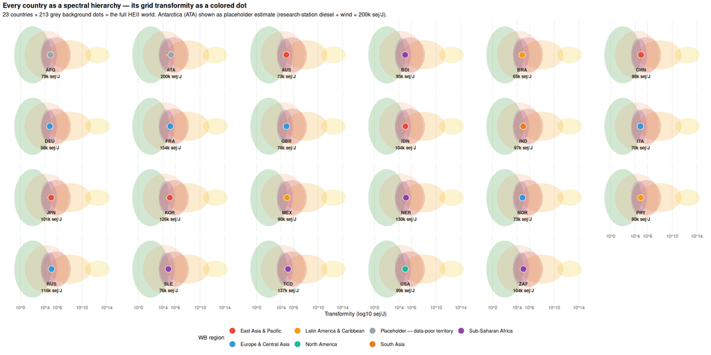

### Time-series — 125 years of transformity drift

Extended Ember (2000-2025, 213 countries) back to **1900 via OWID Etemad-Luciani/Shift Project + EI Statistical Review synthesis** (79 countries, per-fuel primary consumption normalized to shares — `scripts/build_fuel_mix_extended.R` in emburdensynth). The 125-year animation shows country dots + median Grid/HH position sliding as fuel-mix transforms:

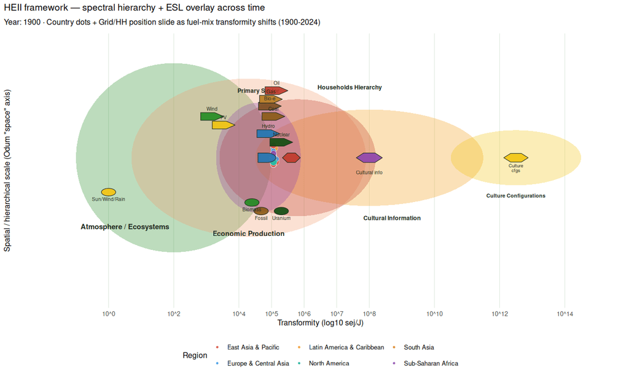

Data floor: **1900** now (Bundle T). Pre-1965 data via OWID’s combined dataset (Etemad-Luciani for oil/gas, Shift Project for coal). Pre-1900 would need Malanima 2020 PDF-table extraction — still open.

### Prior art: this may be the first R Odum ESL geom library

A deep scan of CRAN, GitHub, PyPI, and the Emergy Synthesis proceedings turned up **essentially zero prior art** for programmatic Odum ESL diagrams in the grammar of graphics. The closest peers: `EmSim` (Java, abandoned, ODE integrator — no rendering API), sholtomaud/odum-energy-language (TypeScript GUI drag-and-drop, no data binding), and static SVG references from UF CEP + the International Society for the Advancement of Emergy Research. `emburdensynth::odum_*` (7 `geom_polygon`-returning helpers) appears to be the **first library allowing ESL symbols to be authored programmatically and overlaid on real data in a grammar-of-graphics idiom**.

### The Odum spectral hierarchy — with HEII data

Odum’s **spectral hierarchy** figure (Abel 2023, fig 21 — [International Journal of General Systems](https://www.tandfonline.com/doi/full/10.1080/03081079.2022.2162048)) lays out the biosphere along a single log-transformity axis: sunlight at the low end, cultural information at the high end, with nested lens/spindle shapes for each domain (atmosphere, ecosystems, economic production, households, cultural information). Larger transformity = more accumulated solar-emergy per joule = higher in the hierarchy. We can render the same figure with our real HEII data.

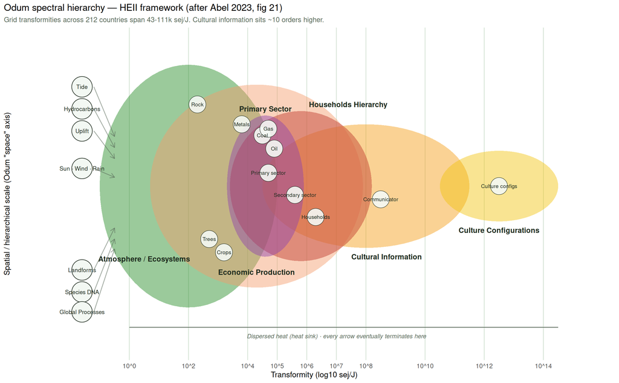

Odum spectral hierarchy for the HEII framework — after Abel 2023 fig 21 (Int J General Systems). X = log10 transformity (sej/J). Country positions use the Q3.14 renewable-adjusted transformity (fuel-mix reconstruction with full-chain LCA-emergy for renewables), not the pipeline’s efficiency-corrected metric — the classical hierarchy is directionally correct on this measure. Nested progressively-right-shifted lenses show the biosphere hierarchy from atmosphere/ecosystems (leftmost, most territory) to cultural information (rightmost, highest concentration per joule).

The diagram makes visible what a bar chart or table can’t: **our entire HEII framework occupies a narrow band around 10⁴-10⁵ sej/J** on Odum’s full log scale. Cultural information — the ultimate output of the biosphere hierarchy — sits ~10 orders of magnitude to the right. The “energy insecurity” we measure at the household level is one plateau on a much longer ramp; households that never reach that plateau also never access the cultural-information tiers above it.

### The Odum emergy pyramid — with real numbers

[figure not shown]

Odum’s emergy pyramid — with real world electricity generation. Each fuel’s transformity (electricity-basis) sets its position on the y-axis; the width of each tier is proportional to that fuel’s global generation share. Nuclear + hydro concentrate massive prior emergy into a small joule count; solar + wind sit at the base with little prior investment.

Backward-compatible with the existing insecurity score

The Round-19 `country_unified_metrics()` function (EJ-native) computed

```
insecurity_score = max(0, 1 −
actual_ej/required_ej)
```

— physical adequacy only, no economic term. HEII is additive to that: it retains physical adequacy AND introduces the economic axis in the same currency. Both are preserved in the cache; `unified_comparison()` joins them for cross-checking. See Layer M.7 in the tech report for the sign-agreement diagnostic.

## The math (short version)

```r
library(emburdensynth)

# Transformity of the fuel mix in a country-year (electricity-basis,
# post-Bundle-A: fossil transformities divided by their electric efficiency)
grid_transformity("NOR", 2023)   # hydro-heavy — moderate (~73k sej/J)
grid_transformity("FRA", 2023)   # nuclear-heavy — highest tier (~150k)
grid_transformity("DNK", 2023)   # wind + biomass — biomass lifts it (~33k)
grid_transformity("POL", 2023)   # coal-heavy — high (~88k, was ~35k pre-Bundle-A)

# Household empower — sej/yr delivered per household
household_empower("USA", 2020, kwh_per_year = 11000)  # sej per year

# Emergy Sustainability Index (Odum)
household_ESI("NOR", 2020)  # named vec: R_pct, NR_pct, ELR, EYR, ESI

# National empower / GDP
emergy_per_money("FRA", 2020)                    # sej per $
```

All functions ship in the [`emburden` R package](https://github.com/ericscheier/emburdensynth/blob/global/R/emergy.R). The full metric table for 213 countries is at [`docs/global_analysis_data/emergy_metrics.rds`](https://github.com/ericscheier/emburdensynth/tree/global/docs/global_analysis_data).

Additive, not replacement

Emergy accounting does not supersede CO<sub>2</sub> accounting. They answer different questions. The climate-justice mismatch (67× per-capita cumulative CO<sub>2</sub> disparity) still stands as a headline for who pays what. Emergy adds a quality axis: *what kind* of energy they pay for.

## The six panels

The technical report (Layer M, pp 82–91) shows six emergy figures:

1. Grid transformity world map (sej/J)
2. Country empower per capita world map (sej/person/yr)
3. ESI vs GDP-pc scatter (weak correlation)
4. Household em/USD arbitrage scatter
5. Cell-level %R world map (17,028 cells)
6. Cell-level emergy insecurity gap (sej/yr)

See also: The Atlas · Methods · Data provenance · Papers · Code